# Calculating Movement Path Metrics in R

Briana Abrahms

September 10th 2019

```r
library(tidyverse)
library(sf) #for simple feature spatial data
library(move) #for loading data from Movebank and calculating some path metrics
library(adehabitatLT) # for calculating large suite of path metrics
library(knitr)
```

# Movement data

Movement data may come in a variety of scales and resolutions, requiring careful consideration before analysis.

Here we are going to focus on GPS relocation data as it is one of the most common forms of tracking data and provides a (mostly) consistent record of an animals movement path.

There are many packages in R used to handle movement data, and an ever growing number built for specific analyses. Unfortunately there is no strict consensus yet on which class of movement data objects should be in across packages, and researchers often have to be comfortable converting from one to the other depending on the task at hand and the format required by each package. Although there are definitely more R packages created for dealing with animal movement data, I am going to focus today on the two most prominent: `move` and `adehabitatLT`.

To begin we are going to introduce Movebank and `Move` & `MoveStack` objects with the library `move`. We will then introduce the `adehabitatLT` package and demonstrate how easy it is to pull out primary stepwise characteristics like step length, turning angle, and net displacement from our trajectories. These primary path characteristics often form the basis for many more complex movement analyses.

## Movebank & the `move` package

Though often researchers in your position will have data of your own, there has been an effort to share movement data from other collections through the Movebank database. Movebank is a free online infrastructure created to help researchers manage, share, analyze, and archive animal movement data. `move` is an R package that contains functions to access movement data stored in movebank.org as well as tools to visualize and statistically analyze animal movement data. `move` is addressing movement ecology questions that complement existing efforts such as `adehabitat` and other packages which we will introduce later.

There are 3 ways to load movement data into R as a `move` object:

1. Using the movebank API
2. Directly loading movebank-formatted .csvs
3. Converting data from a traditional dataframe

Here let’s consider some Albatross data, from movebank study #2911040. To load data directly from the movebank API like I will here, you would need your own movebank username and password, here I have stored my password in my local environment as the variable `pass`.

```r
loginStored <- movebankLogin(username="briana.abrahms", password=pass)

#let's look at a study with albatross data
getMovebankStudy(2911040, login=loginStored)$citation

#if you want to search for studies by a search term
# searchMovebankStudies(x="albatross", login=loginStored)

#check for animal IDs -
getMovebankAnimals(2911040, login=loginStored)
#get the all data - getMovebankData()
#get only specific animal by specifying individual_id

albatross <- getMovebank("event", study_id = 2911040, login=loginStored)

head(albatross)

# readr::write_tsv(albatross, "Study2911040") #save as write.csv but faster and without row names
# getMovebank("event", login, study_id,...): returns the sensor measurements from a study.
# See also getMovebankData, getMovebankNonLocationData.
```

To save us the effort of getting you all Movebank logins, I have provided the tsv. We can use this to demonstrate the 3rd way of loading in movement data.

```r
albatross <- read_tsv("data_files/Study2911040", comment="##", col_types = "Tnncc") %>% # Tnncc = time, number, number, character, character
  as.data.frame() %>%
  na.omit()

#create 'move' object
albatross_move <- move(x=albatross$location_long,
              y=albatross$location_lat,
              time=albatross$timestamp,
              data=albatross,
              animal = as.factor(albatross$individual_id),
              sensor = as.factor(albatross$tag_id),
              proj=CRS("+proj=longlat +ellps=WGS84"))

albatross_move
```

```
## class       : MoveStack
## features    : 16028
## extent      : -91.3732, -77.51874, -12.79464, 0.1821983  (xmin, xmax, ymin, ymax)
## crs         : +proj=longlat +ellps=WGS84
## variables   : 3
## names       :      timestamp, location_lat, location_long
## min values  : 1212240571.998,   -12.794643,   -91.3732007
## max values  : 1225994455.998,    0.1821983,   -77.5187383
## timestamps  : 2008-05-31 13:29:31 ... 2008-11-06 18:00:55 Time difference of 159 days  (start ... end, duration)
## sensors     : 2911107, 2911109, 2911114, 2911120, 2911125, 2911131, 2911134, 2911130, 2911111, 2911108, 2911110, 2911115, 2911116, 2911117, 2911118, 2911119, 2911112, 2911113, 2911121, 2911122, 2911123, 2911128, 2911124, 2911126, 2911127, 2911129, 2911132, 2911133
## indiv. data : individual_id, tag_id
## min ID Data : 2911059, 2911107
## max ID Data : 2911095, 2911134
## individuals : X2911059, X2911060, X2911061, X2911062, X2911063, X2911064, X2911065, X2911066, X2911067, X2911074, X2911075, X2911076, X2911077, X2911078, X2911079
## date created: 2019-05-17 06:11:53
```

```r
class(albatross_move)
```

```
## [1] "MoveStack"
## attr(,"package")
## [1] "move"
```

```r
head(albatross_move)
```

```
##             timestamp location_lat location_long
## 1 2008-05-31 13:30:02    -1.372641     -89.74021
## 2 2008-05-31 15:00:44    -1.372894     -89.74015
## 3 2008-05-31 16:30:39    -1.372881     -89.74014
## 4 2008-05-31 18:00:49    -1.372891     -89.74016
## 5 2008-05-31 19:30:18    -1.372912     -89.74013
## 6 2008-05-31 21:00:20    -1.372904     -89.74017
```

We’ve created our own MoveStack, which is a stack of dataframes for each individual. We can plot it using the move::plot command.

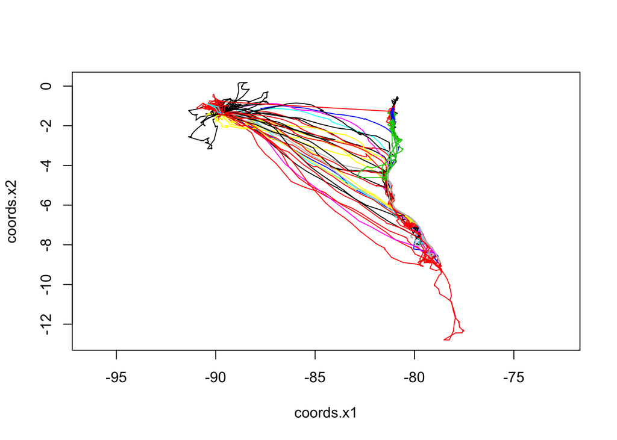

```r
plot(albatross_move, type="l") # all of them
```

If we are curious to compare behaviors across individuals, we can split the moveStack, into separte move objects with the command `split`

```r
ids <- split(albatross_move)
```

This allows us to plot and manipulate the individuals separately:

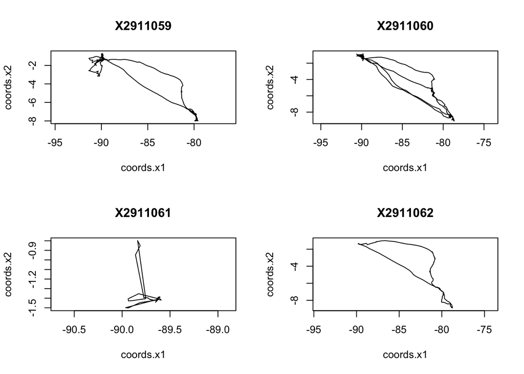

```r
par(mfrow=c(2,2))
plot(ids[[1]], type='l', main= names(ids[1]))
plot(ids[[2]], type='l', main= names(ids[2]))
plot(ids[[3]], type='l', main= names(ids[3]))
plot(ids[[4]], type='l', main= names(ids[4]))
```

We can manipulate, and clean up, this data easily when converted to an sf object from the sf (“simple features”) package for working with simple spatial data.

### Side note: the `sf` package

The **sf** library is an R implementation of:  
- a new spatial data class system in R  
- functions for reading and writing spatial data  
- tools for spatial operations on vectors

Ultimately this seeks to replace the older **sp**, **rgdal**, **rgeos** packages which formed the original toolset for working with spatial data in R. The **sf** library replaces the S4 class structure used in **sp** with simple feature access - the current standard across industry for organizing spatial data – extending R’s data.frame structure directly to accept spatial geometry attributes and making it easier to manipulate spatial datasets using tools like dplyr and the tidyverse. However, as this package is new and under developement there are times were we will switch back to the S4 class structure to play nice with our movement packages.

More information regarding this shift [here](https://www.r-consortium.org/blog/2017/01/03/simple-features-now-on-cran)

```r
albatross_sf <-
  albatross %>%
  st_as_sf(coords = c("location_long", "location_lat"), crs=4326)
```

This comes in handy for some of the data visualization we will be doing later. In addition, in this state, it’s simple to interogate the data, such as looking at how many records we have per individual:

```r
albatross_sf %>%
  group_by(individual_id) %>%
  tally()
```

```
## Simple feature collection with 28 features and 2 fields
## geometry type:  MULTIPOINT
## dimension:      XY
## bbox:           xmin: -91.3732 ymin: -12.79464 xmax: -77.51874 ymax: 0.1821983
## epsg (SRID):    4326
## proj4string:    +proj=longlat +datum=WGS84 +no_defs
## # A tibble: 28 x 3
##    individual_id     n                                             geometry
##  * <chr>         <int>                                     <MULTIPOINT [°]>
##  1 2911059         757 (-91.3732 -2.555532, -91.35647 -2.549766, -91.3552 …
##  2 2911060        1113 (-90.60519 -0.8766839, -90.58503 -1.132963, -90.580…
##  3 2911061         182 (-89.96382 -1.498904, -89.93767 -1.405967, -89.9360…
##  4 2911062         573 (-89.78324 -1.323679, -89.78296 -1.349104, -89.7814…
##  5 2911063         757 (-90.23449 -0.9374604, -90.22138 -0.9420038, -90.20…
##  6 2911064         633 (-89.91398 -1.210413, -89.89134 -1.437677, -89.8853…
##  7 2911065         977 (-90.4803 -1.484479, -90.43625 -1.439869, -90.4063 …
##  8 2911066         647 (-89.86878 -1.414297, -89.86041 -1.415959, -89.8503…
##  9 2911067        1503 (-90.24489 -1.325544, -90.23058 -1.280133, -90.1990…
## 10 2911074        1326 (-90.95079 -1.096899, -90.88568 -1.145157, -90.6931…
## # … with 18 more rows
```

```r
# we could do something similar on the movestack by calling...
table(albatross_move@trackId)
```

```
##
## X2911059 X2911060 X2911061 X2911062 X2911063 X2911064 X2911065 X2911066
##      757     1113      182      573      757      633      977      647
## X2911067 X2911074 X2911075 X2911076 X2911077 X2911078 X2911079 X2911080
##     1503     1326       32       53      189       46       67       48
## X2911084 X2911085 X2911086 X2911087 X2911088 X2911089 X2911090 X2911091
##       22      243      140       96       58        4      150     1338
## X2911092 X2911093 X2911094 X2911095
##      974     1552     2339      209
```

## Calculate Path Characteristics

We can use additional functions in the `move` package to calculate some path characteristics.

- Step Length: the distance between successive relocations is often used in animal movement analysis (e.g. Root and Kareiva 1984, Marsh and Jones 1988). The `move` package automatically calculates distances in meters if the coordinates are projected in long/lat degrees, so no conversion is necessary.

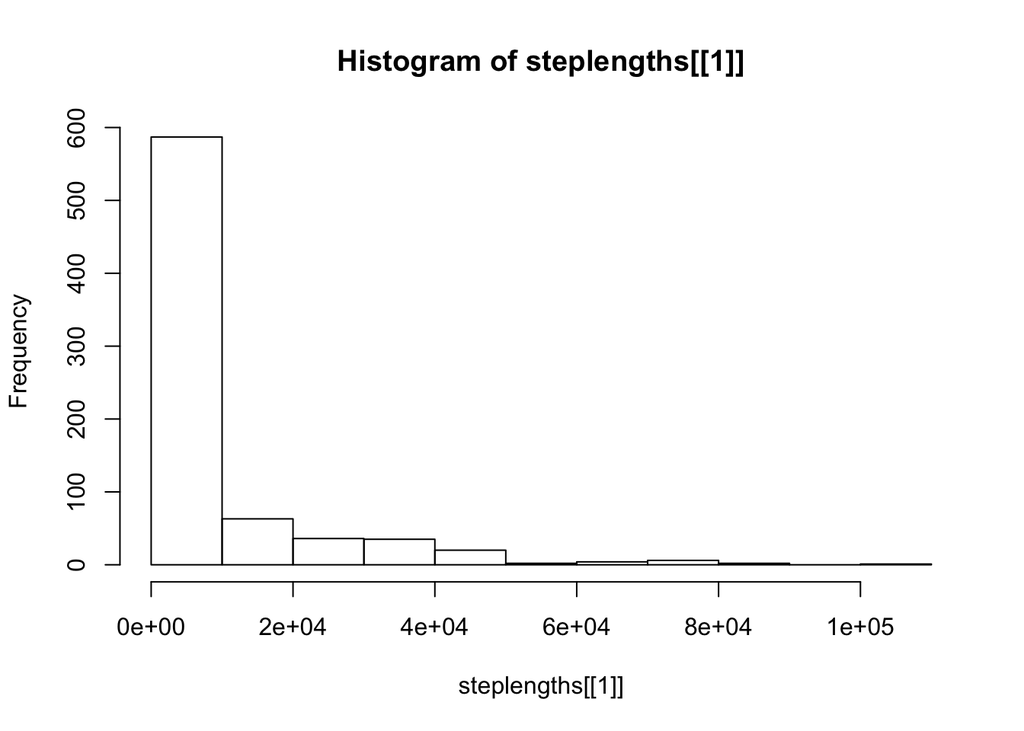

```r
steplengths <- distance(albatross_move)

hist(steplengths[[1]])
```

- Turning Angle Your turning angle measures the change of direction between the step built by relocations i − 1 and i and the step built by relocations i and i + 1 (what we generally refer to as “turning angle”). It is often used together with the parameter dist to fit movement models (e.g. Root and Kareiva 1984, Marsh and Jones 1988).

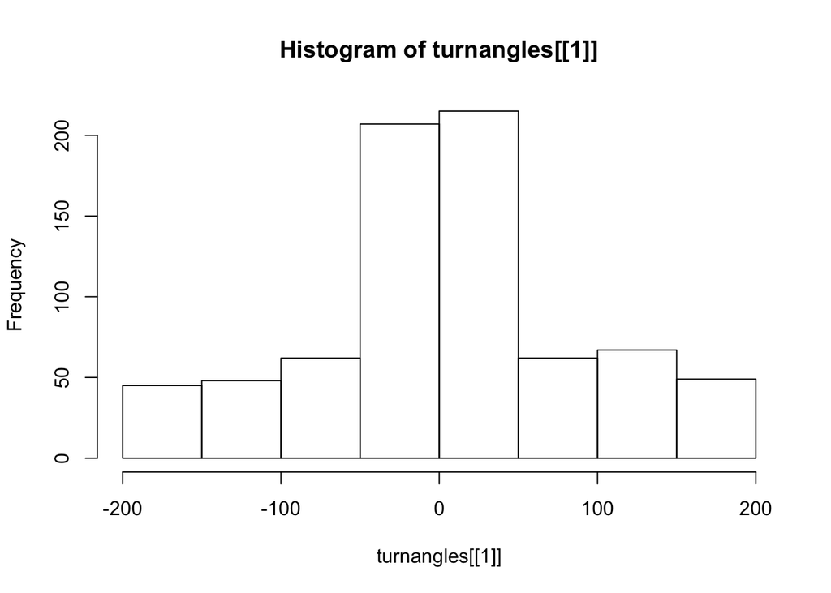

```r
turnangles <- turnAngleGc(albatross_move)

hist(turnangles[[1]])
```

- Speed: the speed between successive relocations (in meters/second for long/lat projection) can often help identify if there are any outliers based on unrealistic movement speeds.

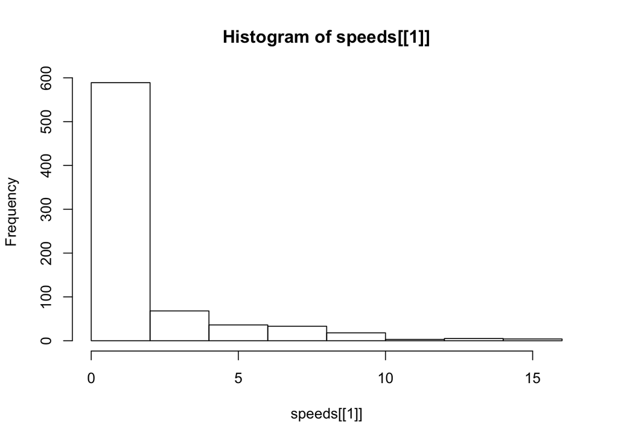

```r
speeds <- speed(albatross_move)

hist(speeds[[1]])
```

There is lots more the `move` package has to offer, but we are going to move onto ltraj objects and the primary path characteristics they make so easy to extract.

## AdehabitatLT package

The ‘adehabitatLT’ package works with ‘ltraj’ objects. The class ltraj is intended to store trajectories of animals. `ltraj` objects function neatly as lists, similar in some ways to the list of Move objects that was created when we split out albatross MoveStack. A key difference between Move and ltraj objects is not only in the structure of data but also the attributes calculated. Ltraj ojects automatically calculate common path characteristics like step length, relative turning angle, absolute turning angle, and net squared displacement from which much of subsequent movement modelling builds off of. Additionally from these primary path characteristics it’s simple to calculate secondary statistics like sinuosity, residence time, or directional persistence.

`ltrajs` can be created from a traditional data frames, spatial dataframes, or directly from move objects using the command `as.ltraj` and, in the case of the dataframes, specifying the coordinates.

Before we create an ltraj object below, we will first add in UTM coordinates. This is necessary for calculating path metrics in meters because unlike the `move` package, `adehabitatLT` does not automatically convert long/lat projections into meters.

```r
#add UTM coordinates
coords <- sp::SpatialPoints(data.frame(albatross$location_long, albatross$location_lat), proj4string=CRS("+proj=longlat +ellps=WGS84"))
UTM_coords <- spTransform(coords, CRS("+proj=utm +south +zone=16 +ellps=WGS84")) # reproject to UTM (meters)
albatross$utm_long <- UTM_coords@coords[,1]
albatross$utm_lat <- UTM_coords@coords[,2]

# create 'ltraj' object
alba_ltraj  <- as.ltraj(xy=cbind(albatross$utm_long, albatross$utm_lat),
                        date=albatross$timestamp,
                        id=as.factor(albatross$individual_id),
                        proj4string = CRS("+proj=utm +south +zone=16 +ellps=WGS84"))

alba_ltraj
```

```
##
## *********** List of class ltraj ***********
##
## Type of the traject: Type II (time recorded)
## * Time zone: UTC *
## Irregular traject. Variable time lag between two locs
##
## Characteristics of the bursts:
##         id   burst nb.reloc NAs          date.begin            date.end
## 1  2911059 2911059      757   0 2008-05-31 13:30:02 2008-07-17 21:00:44
## 2  2911060 2911060     1113   0 2008-05-31 14:59:31 2008-08-09 18:00:18
## 3  2911061 2911061      182   0 2008-06-23 17:58:02 2008-07-11 10:32:29
## 4  2911062 2911062      573   0 2008-05-31 13:29:55 2008-07-06 12:00:26
## 5  2911063 2911063      757   0 2008-05-31 14:59:30 2008-07-17 22:31:01
## 6  2911064 2911064      633   0 2008-05-31 14:59:55 2008-07-11 12:00:43
```

[output cut: 26 more lines]

```r
# note that we can also convert our move object directly into an ltraj object, but that will retain the long/lat projection
# alba_ltraj  <- as(albatross_move, 'ltraj')
```

Note the information the this class gives us up front. Not only can we see the number of relocations from each of our animals we can see exactly the start and end dates of each trajectory.

We can quickly plot all individuals or just specific ones.

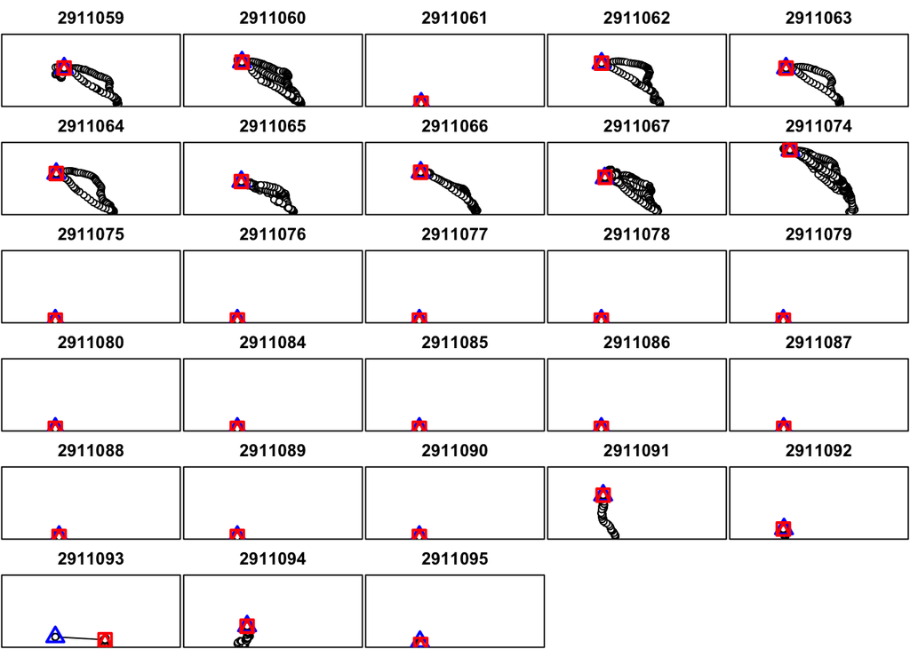

```r
plot(alba_ltraj)
```

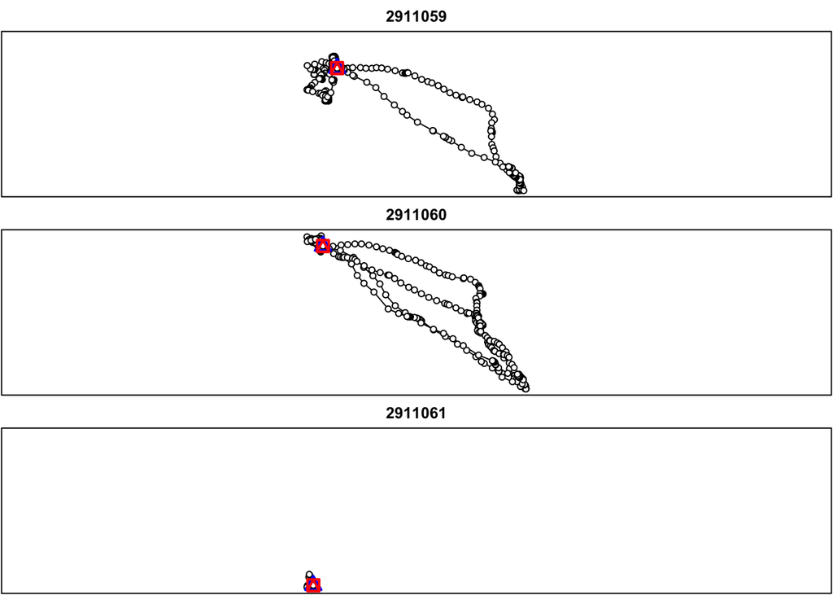

```r
plot(alba_ltraj[1:3])
```

# Automatic Path Characteristics

If we dig into any one of our ltraj list objects, we’ll see a dataframe containing certain basic characteristics from our paths. Specifically we get **step length**, **turn angle**, and **net squared displacement** automatically whenever we create an ltraj object. That is very convenient! Keep in mind the x and y coordinates need to be in UTM in order for distance and displacement metrics to be calculated in meters.

```r
#let's look at a dataframe in the ltraj list
#it is very easy in the ltraj list format to grab different individuals
#for example here is the dataframe for the first individual

head(alba_ltraj[[1]])
```

```
##          x       y                date        dx          dy      dist
## 1 195052.8 9848107 2008-05-31 13:30:02  6.692118 -27.9998822 28.788502
## 2 195059.5 9848079 2008-05-31 15:00:44  1.568660   1.4624852  2.144658
## 3 195061.0 9848080 2008-05-31 16:30:39 -2.170446  -1.1312011  2.447540
## 4 195058.9 9848079 2008-05-31 18:00:49  3.633369  -2.3196527  4.310703
## 5 195062.5 9848077 2008-05-31 19:30:18 -4.478192   0.9243924  4.572603
## 6 195058.0 9848078 2008-05-31 21:00:20  1.148013  -0.7732899  1.384164
##         dt      R2n  abs.angle rel.angle
## 1 5442.997   0.0000 -1.3361922        NA
## 2 5395.000 828.7778  0.7503845  2.086577
## 3 5410.000 772.4739 -2.6611420  2.871659
## 4 5369.000 802.6435 -0.5681988  2.092943
## 5 5401.002 993.8456  2.9380308 -2.776956
## 6 5424.000 872.2232 -0.5927805  2.752374
```

Here we see step length (`dist`), turn angle (`rel.angle`), absolute angle (`abs.angle`), and net squared displacement (`R2n`). Whereas the relative turning angle measures the change of direction between the step built by relocations i − 1 and i and the step built by relocations i and i + 1, the absolute angle is the angle between the x direction and the step built by relocations i and i + 1.

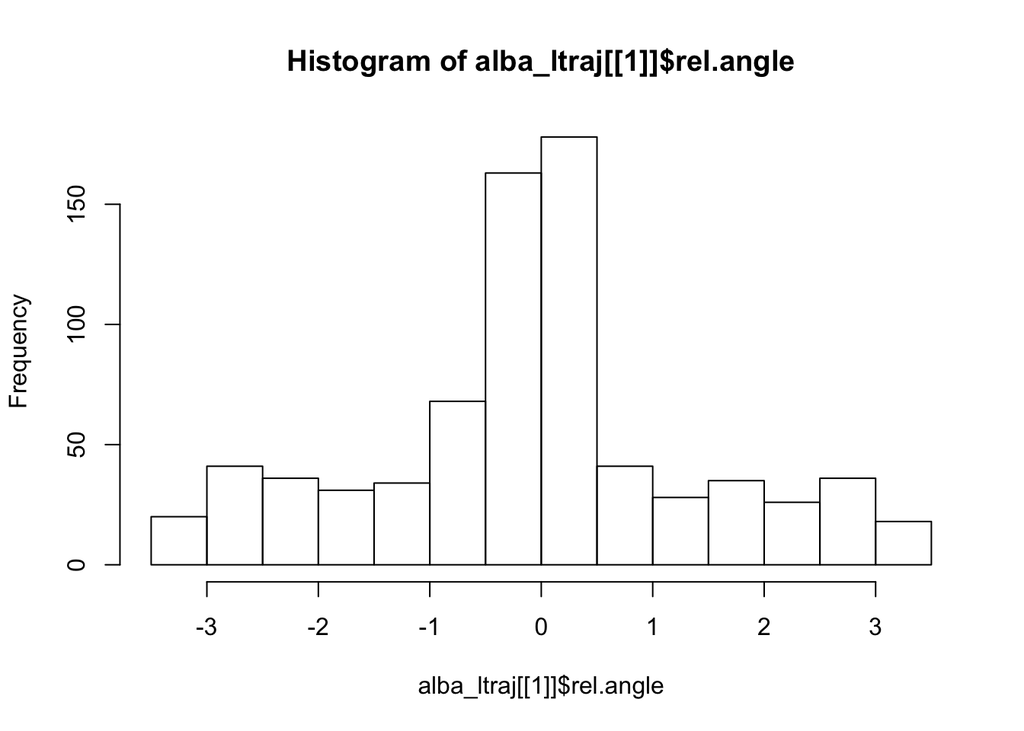

```r
hist(alba_ltraj[[1]]$rel.angle)
```

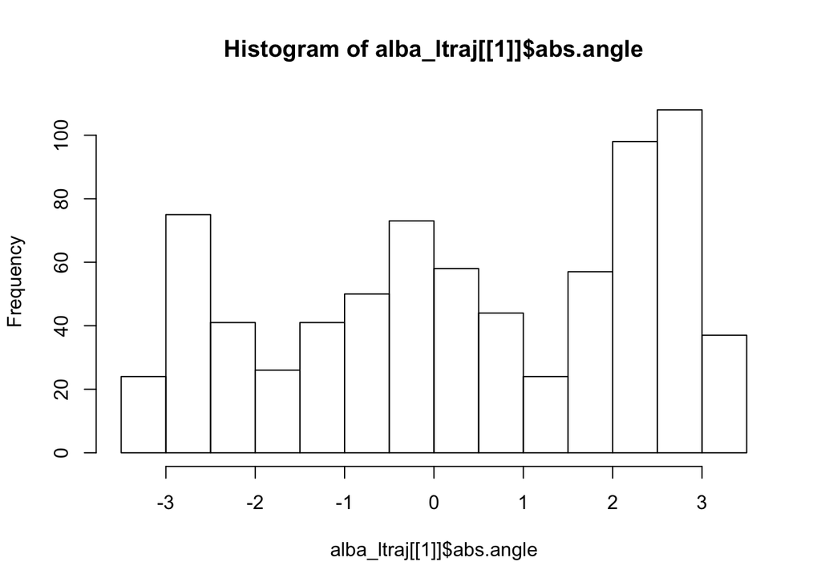

```r
hist(alba_ltraj[[1]]$abs.angle)
```

- Net Squared Displacement, i.e R2n,the squared distance between the first relocation of the trajectory and the current relocation is very significant in animal movement ecology. It is often used to test some movements models (e.g. the correlated random walk, see the seminal paper of Kareiva and Shigesada, 1983). It is also widely used to identify broad-scale movement patterns like range residency, migration, nomadism, dispersal (see Bunnefeld et al. 2010).

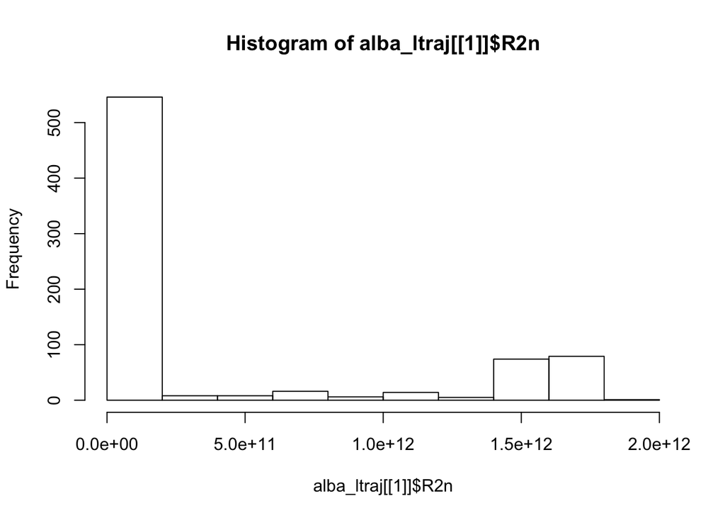

```r
hist(alba_ltraj[[1]]$R2n)
```

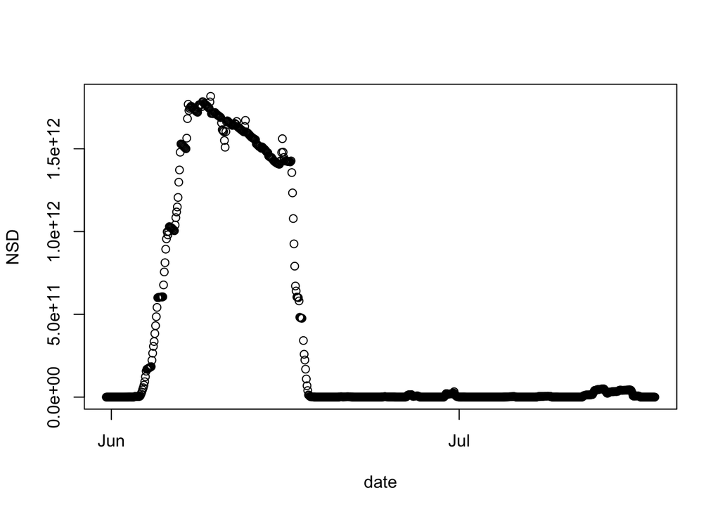

```r
#let's look at NSD over time
plot(alba_ltraj[[1]]$date, alba_ltraj[[1]]$R2n, xlab="date", ylab="NSD") #this looks like classic migratory behavior
```

Note the distributions plotted above as they often form the basis for accurate simulations of animal movement paths.

From these metrics we can also calculate secondary characteristics such as *velocity*, *straightness*, *sinuosity*, *directional persistence*, *persistence velocity*, *residence time*, *time to return*, and more.

In addition to the derivation of these primary and secondary path characteristics, adehabitatLT is especially useful for path segementation and some simple movement models. If interested, I highly recommend consulting the package’s very thourough documentation. You can also explore vignettes of the adehabitatLT package [here](https://cran.r-project.org/web/packages/adehabitatLT/).

### Side note: types of trajectories in adehabitatLT

The adehabitat packages, and ltraj objects, distinguish between 2 types of trajectories: 1. Trajectories of type I are characterized by the fact that the time is not precisely known or not taken into account for the relocations of the trajectory (i.e. sampling of tracks in snow) 2. Trajectories of type II are characterized by the fact that the time is known for each relocation. This type of trajectory is in turn be divided into two subtypes: – regular trajectories: these trajectories are characterized by a constant time lag between successive relocations; – irregular trajectories: these trajectories are characterized by a variable time lag between successive relocations

It’s worth emphasizing that functions in `adehabitatLT` are mainly designed to deal with type I or type II regular trajectories. Irregular trajectories are harder to analyze as their descriptive parameters may not be compared when computed on different time lags.